# Voronoi diagrams and voting

# Voronoi cells

Given a discrete subset of $D \subset \mathbb{R}^d$, you can imagine that $D$ is a realization of a Poisson point process, we associate to each $x \in D$, its *Voronoi cell* $V(x) \subseteq \mathbb{R}^d$, which consists of all the points $y \in \mathbb{R}^d$, such that $\| x- y\| < \|z - y\|$ for all $z \in D \setminus \{x\}$. You can imagine that each point (cellphone location) $y \in \mathbb{R}^d$ would like to report to the nearest (cellphone tower) point in $D$, and $V(x)$ is all the points that report to $x$. For more information see [wiki link](https://en.wikipedia.org/wiki/Voronoi_diagram).

# A simple voting model

Here we consider a simple voting model studied in by [Quas](https://www.math.uvic.ca/~aquas/papers/paper23.pdf). Suppose we have $n$ candidates, and their political positions are represented on a point on the unit interval $[0,1]$, and subsets of $[0,1]$ represents a share of the voters. The support that each candidate has, is given by their Voronoi cell. The candidates go through, $n-1$ rounds of election, where in each round, the candidate with the least support drops out.

- Plot a histogram of the position of the winner, when $n$ is large, and the candidates are uniformly distributed on $[0,1]$

## Solutions

Given a set of points (candidates) on the unit interval, the function V computes length of the interval those points would claim under the Voronoi tessellation; this is the length of the area of support corresponding to each candidate. Notice that we treat the endpoints separately.

```r
V <- function(x){
y = sort(x, decreasing =F)
L = length(y)
d = y[1] + (y[2] - y[1])/2
if (L>2) {
for (i in 2 :(L-1))
d <- c(d, (y[i] - y[i-1])/2 + (y[i+1] - y[i])/2)
}
d <- c(d, (y[L]-y[L-1])/2 + 1-y[L])
d
}
```

The following version of V does not use a *for* loop, and may be faster.

```r
VV <- function(x){
y = sort(x, decreasing =F)
L = length(y)
d = y[1] + (y[2] - y[1])/2
w =NULL
if(L >2){
yp <- y[-1]
ye <- y[-L]
w=(yp-ye)/2
w<-w[-length(w)]
ypp<- yp[-1]
yp <- yp[-(L-1)]
w <- w + (ypp - yp)/2
}
 w <- c(d,w, (y[L]-y[L-1])/2 + 1-y[L])
 w
}
```

The following function tells us which candidate drops out.

```r
amin <- function(x){
   which(x==min(x))
}
```

Finally, we need a way of repeating this procedure until there is one winner, where we start with $n$ independent and uniformly distributed candidates.

```r
Loop <- function(n){
x <- runif(n)
y <- sort(x, decreasing=F)
i=1
while(i < n)
{amin(VV(y))
y <- y[-amin(VV(y))]
i <- i+1}
y
}
```

Here, we plot a histogram of the winner, in the case $n=10$ and $n=50$

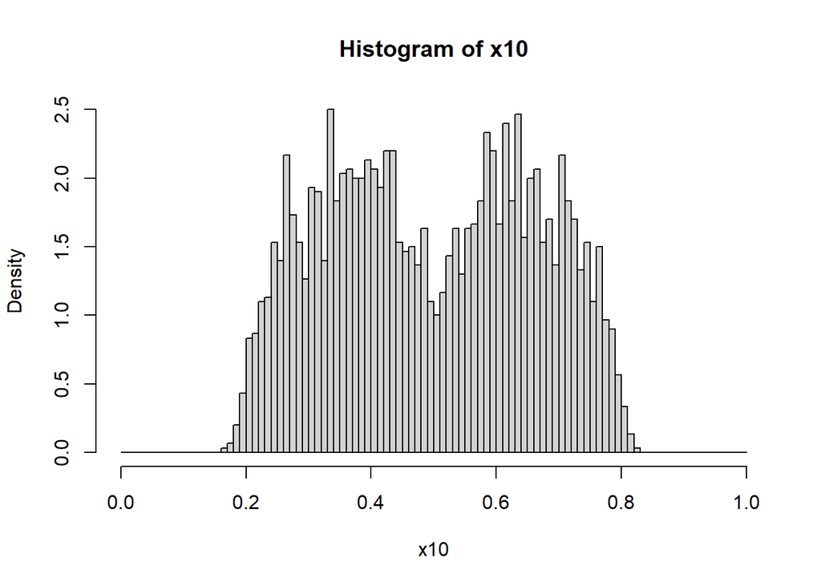

```r
b = seq(0,1, by=0.01)
x10=replicate(3000, Loop(10))

hist(x10, prob=TRUE, breaks=b)
```

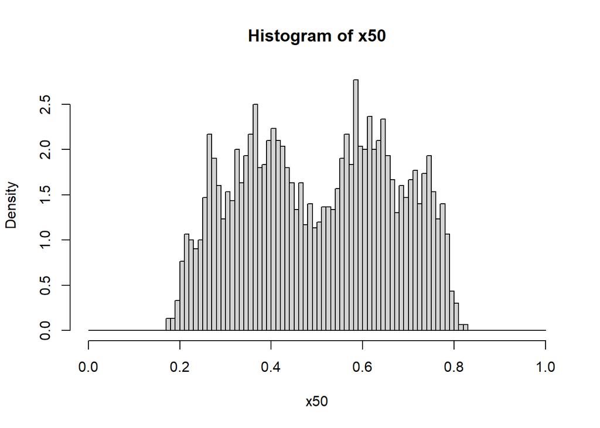

```r
x50=replicate(3000, Loop(50))

hist(x50, prob=TRUE, breaks=b)
```

# Endnotes

- Version: 12 November 2023
- [Rmd Source](https://tsoo-math.github.io/ucl4/week10-2023-inclass-sols.Rmd)